# 36-315 Final Project

## Violin Plot

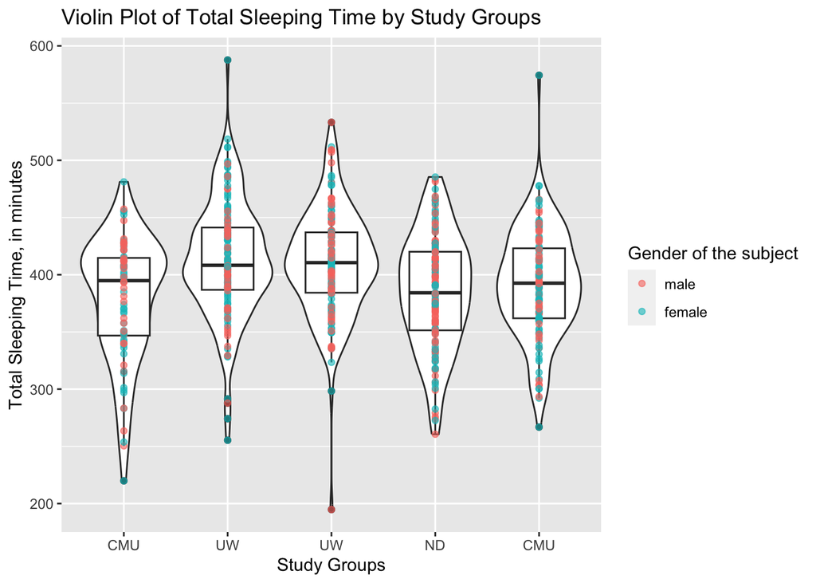

The questions I am interested in exploring are whether CMU students sleep significantly less than students from other universities and whether female students sleep more than male students. This violin plot shows the full shape of the distribution of total sleeping time regarding students from each university, with each specific data point being categorized by the gender of the investigated students. According to the box plots enclosed in the violin shapes, the average median sleeping time among CMU students is not significantly less than that of students from other universities. According to the density curves given by the violin plot, the peaks of the curves for CMU students’ sleeping time are also not significantly lower than those of other universities. We can see that among all universities, most male students tend to have an intermediate amount of sleep while female students are more likely to sleep very little or a lot, except for students from the University of Washington.

## Dendrogram

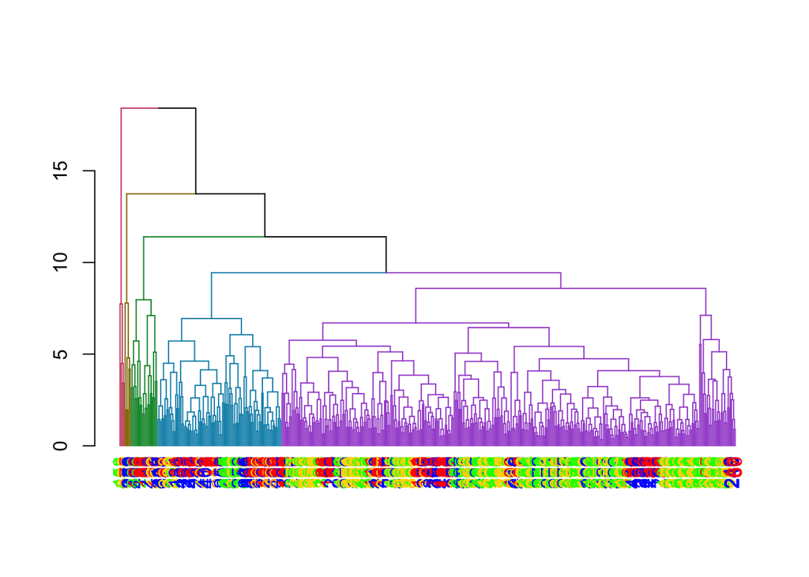

dendrogram (five branches colored, with which study they came from as the label colors)